# ECON 3880: Assignment 5

Samuel Morency - 101065894

2024-08-06

# Questions:

## Question 1

> Using the **statcanR** package, search for the data table that contains “unemployment”, “census”, and “2022” in its title, download that table and call it **LF**.

```r
invisible(lapply(c("statcanR", "tidyverse", "readxl", "regclass"),
       require,
       character.only = TRUE))
```

```
Important regclass change from 1.3:
All functions that had a . in the name now have an _
all.correlations -> all_correlations, cor.demo -> cor_demo, etc.
```

```r
statcan_search(c("unemployment", "census", "2022"), "eng")
```

|  | title | id | description | release_date | lang |
| --- | --- | --- | --- | --- | --- |

```r
LF <- statcan_download_data("14-10-0106-01", "eng")
```

```
statcanR: downloading remote table.
```

```r
LF
```

| REF_DATE | GEO | DGUID | Labour force characteristics | Population centre and rural areas | Sex | Age group | UOM | UOM_ID | SCALAR_FACTOR | SCALAR_ID | VECTOR | COORDINATE | VALUE | STATUS | SYMBOL | TERMINATED | DECIMALS | INDICATOR |
| --- | --- | --- | --- | --- | --- | --- | --- | --- | --- | --- | --- | --- | --- | --- | --- | --- | --- | --- |
| 2011-01-01 | Canada | 2016A000011124 | Population | Total, all population centres and rural areas | Both sexes | 15 years and over | Persons | 249 | thousands | 3 | v91528504 | 1.1.1.1.1 | 27913.3 |  | NA | NA | 1 | Employment and unemployment rate, annual, population centres and rural areas, inactive |
| 2011-01-01 | Canada | 2016A000011124 | Population | Total, all population centres and rural areas | Both sexes | 15 to 24 years | Persons | 249 | thousands | 3 | v91528505 | 1.1.1.1.2 | 4464.7 |  | NA | NA | 1 | Employment and unemployment rate, annual, population centres and rural areas, inactive |
| 2011-01-01 | Canada | 2016A000011124 | Population | Total, all population centres and rural areas | Both sexes | 25 years and over | Persons | 249 | thousands | 3 | v91528506 | 1.1.1.1.3 | 23448.6 |  | NA | NA | 1 | Employment and unemployment rate, annual, population centres and rural areas, inactive |
| 2011-01-01 | Canada | 2016A000011124 | Population | Total, all population centres and rural areas | Both sexes | 25 to 44 years | Persons | 249 | thousands | 3 | v91528507 | 1.1.1.1.4 | 9139.7 |  | NA | NA | 1 | Employment and unemployment rate, annual, population centres and rural areas, inactive |
| 2011-01-01 | Canada | 2016A000011124 | Population | Total, all population centres and rural areas | Both sexes | 45 years and over | Persons | 249 | thousands | 3 | v91528508 | 1.1.1.1.5 | 14308.9 |  | NA | NA | 1 | Employment and unemployment rate, annual, population centres and rural areas, inactive |
| 2011-01-01 | Canada | 2016A000011124 | Population | Total, all population centres and rural areas | Both sexes | 25 to 54 years | Persons | 249 | thousands | 3 | v91528509 | 1.1.1.1.6 | 14444.1 |  | NA | NA | 1 | Employment and unemployment rate, annual, population centres and rural areas, inactive |
| 2011-01-01 | Canada | 2016A000011124 | Population | Total, all population centres and rural areas | Both sexes | 55 years and over | Persons | 249 | thousands | 3 | v91528510 | 1.1.1.1.7 | 9004.4 |  | NA | NA | 1 | Employment and unemployment rate, annual, population centres and rural areas, inactive |
| 2011-01-01 | Canada | 2016A000011124 | Population | Total, all population centres and rural areas | Both sexes | 55 to 64 years | Persons | 249 | thousands | 3 | v91528511 | 1.1.1.1.8 | 4328.2 |  | NA | NA | 1 | Employment and unemployment rate, annual, population centres and rural areas, inactive |
| 2011-01-01 | Canada | 2016A000011124 | Population | Total, all population centres and rural areas | Both sexes | 65 years and over | Persons | 249 | thousands | 3 | v91528512 | 1.1.1.1.9 | 4676.2 |  | NA | NA | 1 | Employment and unemployment rate, annual, population centres and rural areas, inactive |
| 2011-01-01 | Canada | 2016A000011124 | Population | Total, all population centres and rural areas | Males | 15 years and over | Persons | 249 | thousands | 3 | v91528513 | 1.1.1.2.1 | 13729.2 |  | NA | NA | 1 | Employment and unemployment rate, annual, population centres and rural areas, inactive |

[output cut: 990 more lines]

- > Clean the names of the columns

```r
LF <- LF %>% janitor::clean_names()
LF
```

| ref_date | geo | dguid | labour_force_characteristics | population_centre_and_rural_areas | sex | age_group | uom | uom_id | scalar_factor | scalar_id | vector | coordinate | value | status | symbol | terminated | decimals | indicator |
| --- | --- | --- | --- | --- | --- | --- | --- | --- | --- | --- | --- | --- | --- | --- | --- | --- | --- | --- |
| 2011-01-01 | Canada | 2016A000011124 | Population | Total, all population centres and rural areas | Both sexes | 15 years and over | Persons | 249 | thousands | 3 | v91528504 | 1.1.1.1.1 | 27913.3 |  | NA | NA | 1 | Employment and unemployment rate, annual, population centres and rural areas, inactive |
| 2011-01-01 | Canada | 2016A000011124 | Population | Total, all population centres and rural areas | Both sexes | 15 to 24 years | Persons | 249 | thousands | 3 | v91528505 | 1.1.1.1.2 | 4464.7 |  | NA | NA | 1 | Employment and unemployment rate, annual, population centres and rural areas, inactive |
| 2011-01-01 | Canada | 2016A000011124 | Population | Total, all population centres and rural areas | Both sexes | 25 years and over | Persons | 249 | thousands | 3 | v91528506 | 1.1.1.1.3 | 23448.6 |  | NA | NA | 1 | Employment and unemployment rate, annual, population centres and rural areas, inactive |
| 2011-01-01 | Canada | 2016A000011124 | Population | Total, all population centres and rural areas | Both sexes | 25 to 44 years | Persons | 249 | thousands | 3 | v91528507 | 1.1.1.1.4 | 9139.7 |  | NA | NA | 1 | Employment and unemployment rate, annual, population centres and rural areas, inactive |
| 2011-01-01 | Canada | 2016A000011124 | Population | Total, all population centres and rural areas | Both sexes | 45 years and over | Persons | 249 | thousands | 3 | v91528508 | 1.1.1.1.5 | 14308.9 |  | NA | NA | 1 | Employment and unemployment rate, annual, population centres and rural areas, inactive |
| 2011-01-01 | Canada | 2016A000011124 | Population | Total, all population centres and rural areas | Both sexes | 25 to 54 years | Persons | 249 | thousands | 3 | v91528509 | 1.1.1.1.6 | 14444.1 |  | NA | NA | 1 | Employment and unemployment rate, annual, population centres and rural areas, inactive |
| 2011-01-01 | Canada | 2016A000011124 | Population | Total, all population centres and rural areas | Both sexes | 55 years and over | Persons | 249 | thousands | 3 | v91528510 | 1.1.1.1.7 | 9004.4 |  | NA | NA | 1 | Employment and unemployment rate, annual, population centres and rural areas, inactive |
| 2011-01-01 | Canada | 2016A000011124 | Population | Total, all population centres and rural areas | Both sexes | 55 to 64 years | Persons | 249 | thousands | 3 | v91528511 | 1.1.1.1.8 | 4328.2 |  | NA | NA | 1 | Employment and unemployment rate, annual, population centres and rural areas, inactive |
| 2011-01-01 | Canada | 2016A000011124 | Population | Total, all population centres and rural areas | Both sexes | 65 years and over | Persons | 249 | thousands | 3 | v91528512 | 1.1.1.1.9 | 4676.2 |  | NA | NA | 1 | Employment and unemployment rate, annual, population centres and rural areas, inactive |
| 2011-01-01 | Canada | 2016A000011124 | Population | Total, all population centres and rural areas | Males | 15 years and over | Persons | 249 | thousands | 3 | v91528513 | 1.1.1.2.1 | 13729.2 |  | NA | NA | 1 | Employment and unemployment rate, annual, population centres and rural areas, inactive |

[output cut: 990 more lines]

- > keep only ref_date, geo, labour_force_characteristics, population_centre_and_rural_areas, sex, age_group, and value

```r
LF <- LF %>% select("ref_date",
                    "geo",
                    "labour_force_characteristics",
                    "population_centre_and_rural_areas",
                    "sex",
                    "age_group",
                    "value")
LF
```

| ref_date | geo | labour_force_characteristics | population_centre_and_rural_areas | sex | age_group | value |
| --- | --- | --- | --- | --- | --- | --- |
| 2011-01-01 | Canada | Population | Total, all population centres and rural areas | Both sexes | 15 years and over | 27913.3 |
| 2011-01-01 | Canada | Population | Total, all population centres and rural areas | Both sexes | 15 to 24 years | 4464.7 |
| 2011-01-01 | Canada | Population | Total, all population centres and rural areas | Both sexes | 25 years and over | 23448.6 |
| 2011-01-01 | Canada | Population | Total, all population centres and rural areas | Both sexes | 25 to 44 years | 9139.7 |
| 2011-01-01 | Canada | Population | Total, all population centres and rural areas | Both sexes | 45 years and over | 14308.9 |
| 2011-01-01 | Canada | Population | Total, all population centres and rural areas | Both sexes | 25 to 54 years | 14444.1 |
| 2011-01-01 | Canada | Population | Total, all population centres and rural areas | Both sexes | 55 years and over | 9004.4 |
| 2011-01-01 | Canada | Population | Total, all population centres and rural areas | Both sexes | 55 to 64 years | 4328.2 |
| 2011-01-01 | Canada | Population | Total, all population centres and rural areas | Both sexes | 65 years and over | 4676.2 |
| 2011-01-01 | Canada | Population | Total, all population centres and rural areas | Males | 15 years and over | 13729.2 |

[output cut: 990 more lines]

- > only keep 2020 from the ref_date; “Total, all population centres and rural areas” from the population_centre_and_rural_areas; unemployment rate from labour_force_characteristics; and age groups 15-24 years and 25-44 years from the age_group.

```r
LF$ref_date <- LF$ref_date %>% format("%Y")
LF <- LF %>% filter(ref_date == 2020,
              population_centre_and_rural_areas == "Total, all population centres and rural areas",
              labour_force_characteristics == "Unemployment rate",
              age_group %in% c("15 to 24 years", "25 to 44 years"))
LF
```

| ref_date | geo | labour_force_characteristics | population_centre_and_rural_areas | sex | age_group | value |
| --- | --- | --- | --- | --- | --- | --- |
| 2020 | Canada | Unemployment rate | Total, all population centres and rural areas | Both sexes | 15 to 24 years | 20.2 |
| 2020 | Canada | Unemployment rate | Total, all population centres and rural areas | Both sexes | 25 to 44 years | 8.3 |
| 2020 | Canada | Unemployment rate | Total, all population centres and rural areas | Males | 15 to 24 years | 20.9 |
| 2020 | Canada | Unemployment rate | Total, all population centres and rural areas | Males | 25 to 44 years | 8.4 |
| 2020 | Canada | Unemployment rate | Total, all population centres and rural areas | Females | 15 to 24 years | 19.4 |
| 2020 | Canada | Unemployment rate | Total, all population centres and rural areas | Females | 25 to 44 years | 8.2 |
| 2020 | Newfoundland and Labrador | Unemployment rate | Total, all population centres and rural areas | Both sexes | 15 to 24 years | 19.4 |
| 2020 | Newfoundland and Labrador | Unemployment rate | Total, all population centres and rural areas | Both sexes | 25 to 44 years | 11.5 |
| 2020 | Newfoundland and Labrador | Unemployment rate | Total, all population centres and rural areas | Males | 15 to 24 years | 22.9 |
| 2020 | Newfoundland and Labrador | Unemployment rate | Total, all population centres and rural areas | Males | 25 to 44 years | 14.7 |

[output cut: 56 more lines]

- > What are the unemployment rates of males and females aged 25-44 years old in Canada and provinces? To answer, create a table that shows the geo in rows, sex in the columns, and the unemployment rates in different cells

```r
uerates <- LF %>%
  filter(sex != "Both sexes", age_group == "25 to 44 years") %>%
  group_by(geo, sex) %>%
  summarise(unemployment_rate = mean(value)) %>%
  pivot_wider(names_from = sex, values_from = unemployment_rate)
uerates
```

| geo | Females | Males |
| --- | --- | --- |
| Alberta | 9.0 | 10.0 |
| British Columbia | 8.0 | 7.7 |
| Canada | 8.2 | 8.4 |
| Manitoba | 7.0 | 7.3 |
| New Brunswick | 6.2 | 10.6 |
| Newfoundland and Labrador | 8.2 | 14.7 |
| Nova Scotia | 8.0 | 9.8 |
| Ontario | 8.8 | 8.1 |
| Prince Edward Island | 10.5 | 9.7 |
| Quebec | 7.4 | 7.9 |

[output cut: 1 more lines]

- > Create a point plot to visualize the above table.

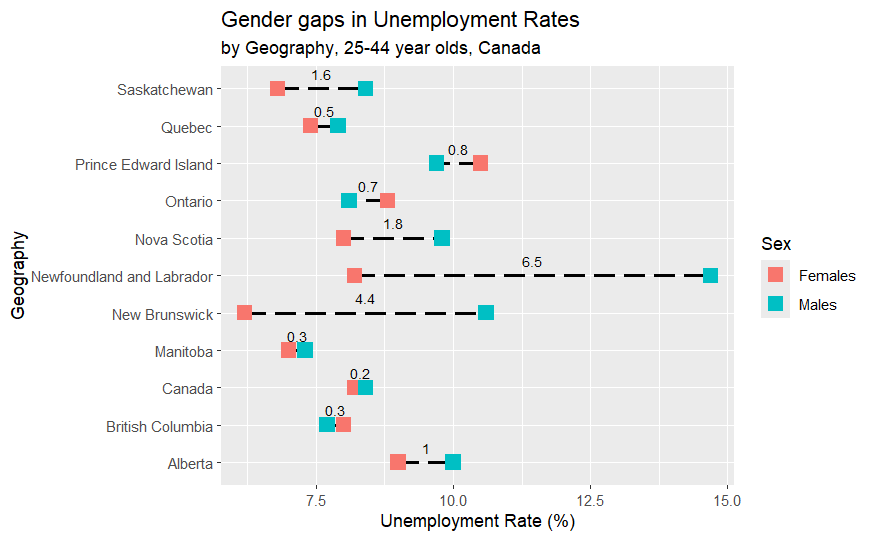

```r
plot1 <- uerates %>%
  ggplot(aes(Females, geo)) +
  geom_segment(aes(xend = Males,
                   yend = geo,
                   linetype = 5),
               linewidth = 1) +
  scale_linetype_identity() +
  geom_point(aes(color = "Females"),
               size = 4,
             shape = 15) +
  geom_point(aes(Males,
                 color = "Males"),
             size = 4,
             shape = 15)

plot1 <- plot1 +
  geom_text(aes(label = abs(uerates$Females - uerates$Males) %>% round(1)),
            position = position_nudge(-(uerates$Females - uerates$Males) / 2, 0.4),
            size = 3) +
  labs(title = 'Gender gaps in Unemployment Rates',
       subtitle = "by Geography, 25-44 year olds, Canada",
       x = 'Unemployment Rate (%)',
       y = 'Geography',
       colour = 'Sex')

plot1
```

- > Where do we observe the biggest gap between the females and males unemployment rate?

```r
gap <- uerates %>% mutate(gap = abs(Females - Males))
gap[which.max(gap$gap),]
```

| geo | Females | Males | gap |
| --- | --- | --- | --- |
| Newfoundland and Labrador | 8.2 | 14.7 | 6.5 |

We observe the biggest gap between the female and male unemployment rates in Newfoundland and Labrador, at 6.5%.

## Question 2

> Write code to import the excel data file named **assignment5_data** from the Brightspace and call it df.

```r
df <- read_excel("Assignment5_data.xlsx", skip = 1)
df
```

| y | x1 | x2 | x3 |
| --- | --- | --- | --- |
| 21.319274 | 83.873945 | 81.935039 | 23.581166 |
| 87.528832 | 23.018334 | 34.563739 | 76.678150 |
| 24.612614 | 97.597989 | 6.288279 | 82.075407 |
| 20.793290 | 94.886986 | 92.789676 | 53.017324 |
| 85.132728 | 97.862962 | 34.717620 | 91.937925 |
| 42.444286 | 2.888232 | 6.341067 | 49.424953 |
| 99.506313 | 36.352390 | 93.507872 | 32.994574 |
| 9.519399 | 48.181221 | 28.694577 | 90.384620 |
| 68.442138 | 95.541032 | 51.348964 | 79.986534 |
| 81.726535 | 74.555861 | 97.552573 | 95.692990 |

[output cut: 18 more lines]

> Estimate the following linear model $y = \beta_0 + \beta_1 * x1+\beta_2 * x2 + \beta_3 * x3$ and show the estimated coefficients.

```r
model1 <- lm(y ~ x1 + x2 + x3, data = df)
coef(model1)
```

```
(Intercept)          x1          x2          x3
32.80489613 -0.11470216  0.34982117  0.06136816
```

> Which one of the independent variables are statistically insignificant?

```r
summary(model1)
```

```
Call:
lm(formula = y ~ x1 + x2 + x3, data = df)

Residuals:
    Min      1Q  Median      3Q     Max
-36.841 -19.005   3.378  13.913  45.766

Coefficients:
            Estimate Std. Error t value Pr(>|t|)
(Intercept) 32.80490   14.81475   2.214   0.0366 *
x1          -0.11470    0.15205  -0.754   0.4580
x2           0.34982    0.14515   2.410   0.0240 *
x3           0.06137    0.18750   0.327   0.7463
---
Signif. codes:  0 ‘***’ 0.001 ‘**’ 0.01 ‘*’ 0.05 ‘.’ 0.1 ‘ ’ 1

Residual standard error: 24.61 on 24 degrees of freedom
Multiple R-squared:  0.2018,    Adjusted R-squared:  0.1021
F-statistic: 2.023 on 3 and 24 DF,  p-value: 0.1375
```

A variable is statistically significant if its p-value is less than 0.05. Therefore, the independent variables x1 and x3 are statistically insignificant, while the intercept and x2 are statistically significant.

## Question 3

> Use the df data:
- > create a new variable called **y_group**, based on the values for y and define y_group = 1 when y > average(y) and 0 otherwise

```r
df_q3 <- df %>% mutate(y_group = if_else(y > mean(y), 1, 0))
```

- > estimate a logistic regression using the y_group as the dependent variable and x1, x2, and x3 as the predictors

```r
df_q3$y_group <- as.factor(df_q3$y_group)

model2 <- glm(y_group ~ x1 +x2 +x3, data = df_q3, family = binomial())
summary(model2)
```

```
Call:
glm(formula = y_group ~ x1 + x2 + x3, family = binomial(), data = df_q3)

Coefficients:
             Estimate Std. Error z value Pr(>|z|)
(Intercept) -1.579055   1.360528  -1.161    0.246
x1          -0.005356   0.013423  -0.399    0.690
x2           0.022050   0.013564   1.626    0.104
x3           0.012371   0.017260   0.717    0.474

(Dispersion parameter for binomial family taken to be 1)

    Null deviance: 38.673  on 27  degrees of freedom
Residual deviance: 35.385  on 24  degrees of freedom
AIC: 43.385

Number of Fisher Scoring iterations: 4
```

- > calculate and show the confusion matrix and the accuracy rate for this model.

```r
cm <- confusion_matrix(model2)
cm
```

```
         Predicted 0 Predicted 1 Total
Actual 0           9           6    15
Actual 1           5           8    13
Total             14          14    28
```

```r
tn <- cm[1,1]
tp <- cm[2,2]
total <- cm[3,3]

accuracy <- (tn + tp) / total
accuracy
```

```
[1] 0.6071429
```

The accuracy rate for this model is ~60.7%.